# Machine Learning for Epidemiology: Assignment 10

April 4th, 2023

In this exercise, we will use real-world exposomic data adapted from the HELIX harmonized birth cohorts in Europe to explore and develop a research question based on high-dimensional epidemiological data (HDD).

The exposomic data contains 4 data frames: exposome, phenotype, covariate and codebook. Exposome contains all of the environmental features measured on children. Phenotype contains health outcomes measured during the study. Covariate contains demographics and maternal information during pregnancy. Codebook is a detailed listing of all variables within the data frames.

We will use these features to try to identify which pre-natal chemical exposures are the greatest risk factors for childhood neurobehavioural problems, as measured through the CBCL scale.

### Load .Rdata file and merge into single data frame

Below we will merge the exposome data, select the features related to pre-natal chemical exposures, select our phenotypic outcome of interest, `hs_Gen_Tot`, and partition the data into a 70/30 training-testing split. Since many of the chemical exposure features may exhibit multicollinearity, we will also remove highly correlated features above a cutoff of 0.4.

```r
library(tidyverse)
library(caret)
library(rpart.plot)
library(kableExtra)
library(corrplot)

#Load data using path of where file is stored
load("./exposome.RData")

#Merge all data frames into a single data frame.

studydata<-merge(exposome,phenotype,by="ID") %>% merge(covariates, by="ID")

#Strip off ID Variable
studydata$ID<-NULL

# Extracting features only related to pre-natal exposure to chemicals and neurobehavioural phenotype outcome
studydata = studydata %>% select(hs_as_m_Log2:hs_tl_mdich_None, hs_dde_madj_Log2:hs_cotinine_mcat_None, hs_Gen_Tot) %>%
  select(contains(c("_m_", "_madj_", "e3_asmokcigd_p_None", "hs_cotinine_mcat_None", "hs_Gen_Tot")))

#Finding correlated predictors
numeric.studydata = studydata %>% select(where(is.numeric))
corplot = cor(numeric.studydata)
correlations<-cor(numeric.studydata, use="complete.obs")
high.correlations<-findCorrelation(correlations, cutoff=0.4)

#Remove highly correlated features
new.data.low.corr <- studydata[,-high.correlations]

#Partition data
set.seed(123)
train.indices<-createDataPartition(y=new.data.low.corr$hs_Gen_Tot, p=0.7, list=FALSE)
train.data<-new.data.low.corr[train.indices, ]
test.data<-new.data.low.corr[-train.indices, ]
```

### Step 1: Exploration of Training Data

```r
summary(train.data) %>% kbl(digits = 3) %>%
  kable_classic(lightable_options = "hover") %>%
  scroll_box(width = "100%", height = "100%")
```

|  | hs_as_m_Log2 | hs_cd_m_Log2 | hs_co_m_Log2 | hs_cs_m_Log2 | hs_cu_m_Log2 | hs_hg_m_Log2 | hs_mn_m_Log2 | hs_mo_m_Log2 | hs_pb_m_Log2 | hs_pfhxs_m_Log2 | hs_pfna_m_Log2 | hs_pfunda_m_Log2 | hs_dde_madj_Log2 | hs_ddt_madj_Log2 | hs_hcb_madj_Log2 | hs_dep_madj_Log2 | hs_detp_madj_Log2 | hs_dmp_madj_Log2 | hs_pbde153_madj_Log2 | hs_pbde47_madj_Log2 | hs_bpa_madj_Log2 | hs_etpa_madj_Log2 | hs_mepa_madj_Log2 | hs_oxbe_madj_Log2 | hs_trcs_madj_Log2 | hs_mecpp_madj_Log2 | hs_mep_madj_Log2 | hs_mnbp_madj_Log2 | hs_ohminp_madj_Log2 | … |
| --- | --- | --- | --- | --- | --- | --- | --- | --- | --- | --- | --- | --- | --- | --- | --- | --- | --- | --- | --- | --- | --- | --- | --- | --- | --- | --- | --- | --- | --- | --- |
|  | Min. :-38.625 | Min. :-7.844 | Min. :-4.7370 | Min. :-0.90779 | Min. : 9.036 | Min. :-9.0230 | Min. :1.655 | Min. :-2.7179 | Min. :1.220 | Min. :-17.8296 | Min. :-10.2118 | Min. :-26.21246 | Min. : 0.8634 | Min. :-14.1418 | Min. :-9.420 | Min. :-13.4083 | Min. :-28.3791 | Min. :-11.898 | Min. :-15.0030 | Min. :-11.5808 | Min. :-11.0198 | Min. :-12.119 | Min. :-0.3096 | Min. :-10.510 | Min. :-4.8110 | Min. : 2.427 | Min. : 3.292 | Min. :-0.7106 | Min. :-11.3438 | … |
|  | 1st Qu.: -5.780 | 1st Qu.:-2.617 | 1st Qu.:-2.4982 | 1st Qu.: 0.07039 | 1st Qu.:10.253 | 1st Qu.:-0.3094 | 1st Qu.:3.336 | 1st Qu.:-0.9921 | 1st Qu.:2.618 | 1st Qu.: -1.7639 | 1st Qu.: -1.3114 | 1st Qu.: -3.21222 | 1st Qu.: 4.4485 | 1st Qu.: -0.2550 | 1st Qu.: 2.309 | 1st Qu.: 0.9887 | 1st Qu.: -4.1804 | 1st Qu.: 2.011 | 1st Qu.: -2.0220 | 1st Qu.: -1.7713 | 1st Qu.: 0.2261 | 1st Qu.: 1.240 | 1st Qu.: 5.9878 | 1st Qu.: 0.689 | 1st Qu.: 0.6145 | 1st Qu.: 4.327 | 1st Qu.: 6.435 | 1st Qu.: 4.1994 | 1st Qu.: -0.7237 | … |
|  | Median : -3.389 | Median :-2.427 | Median :-1.9546 | Median : 0.38957 | Median :10.441 | Median : 0.5753 | Median :3.585 | Median :-0.7322 | Median :3.209 | Median : -0.9284 | Median : -0.5751 | Median : -2.52787 | Median : 5.5677 | Median : 0.7247 | Median : 2.829 | Median : 1.6460 | Median : -0.5251 | Median : 2.839 | Median : -0.9873 | Median : -0.9361 | Median : 1.0872 | Median : 3.280 | Median : 7.7302 | Median : 2.518 | Median : 2.8790 | Median : 4.851 | Median : 7.728 | Median : 4.8522 | Median : -0.1953 | … |
|  | Mean : -3.212 | Mean :-2.162 | Mean :-1.6643 | Mean : 0.47097 | Mean :10.401 | Mean : 0.5650 | Mean :3.548 | Mean :-0.6925 | Mean :3.222 | Mean : -1.0095 | Mean : -0.7401 | Mean : -2.66566 | Mean : 5.8342 | Mean : 0.8784 | Mean : 2.979 | Mean : 1.6709 | Mean : -1.7173 | Mean : 2.206 | Mean : -1.7547 | Mean : -0.7698 | Mean : 1.4155 | Mean : 3.290 | Mean : 7.3419 | Mean : 2.969 | Mean : 3.5183 | Mean : 5.029 | Mean : 7.788 | Mean : 4.9315 | Mean : -0.2639 | … |
|  | 3rd Qu.: 1.037 | 3rd Qu.:-1.699 | 3rd Qu.:-0.5395 | 3rd Qu.: 0.77610 | 3rd Qu.:10.551 | 3rd Qu.: 1.5910 | 3rd Qu.:3.810 | 3rd Qu.:-0.3969 | 3rd Qu.:3.807 | 3rd Qu.: -0.1944 | 3rd Qu.: 0.1317 | 3rd Qu.: -1.72573 | 3rd Qu.: 6.9802 | 3rd Qu.: 1.5209 | 3rd Qu.: 3.495 | 3rd Qu.: 2.6475 | 3rd Qu.: 1.0079 | 3rd Qu.: 3.782 | 3rd Qu.: -0.0321 | 3rd Qu.: 0.1183 | 3rd Qu.: 2.3103 | 3rd Qu.: 5.111 | 3rd Qu.: 8.6247 | 3rd Qu.: 4.671 | 3rd Qu.: 6.7376 | 3rd Qu.: 5.634 | 3rd Qu.: 8.911 | 3rd Qu.: 5.5464 | 3rd Qu.: 0.2784 | … |
|  | Max. : 6.493 | Max. : 4.802 | Max. : 2.5033 | Max. : 3.44626 | Max. :11.116 | Max. : 5.4429 | Max. :5.113 | Max. : 6.1334 | Max. :7.547 | Max. : 3.7592 | Max. : 2.4634 | Max. : -0.04217 | Max. :10.8937 | Max. : 6.5566 | Max. : 7.357 | Max. : 6.0082 | Max. : 5.2559 | Max. : 7.327 | Max. : 6.4338 | Max. : 5.0761 | Max. : 6.7361 | Max. : 12.726 | Max. :14.4057 | Max. : 13.648 | Max. :10.6909 | Max. :10.411 | Max. :14.114 | Max. :11.3441 | Max. : 6.0560 | … |

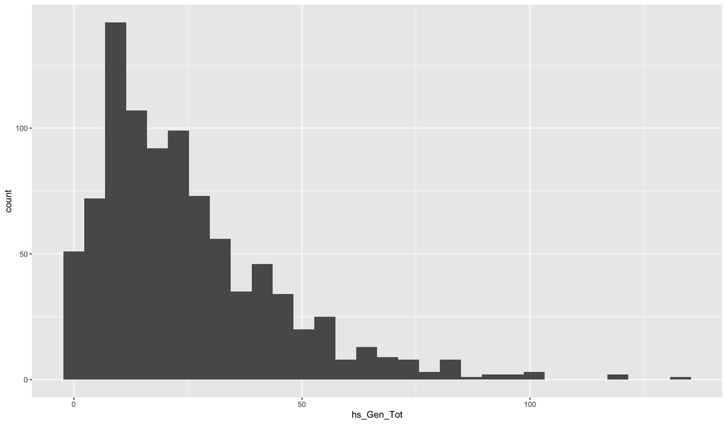

```r
ggplot(data = train.data, aes(x = hs_Gen_Tot)) + geom_histogram()
```

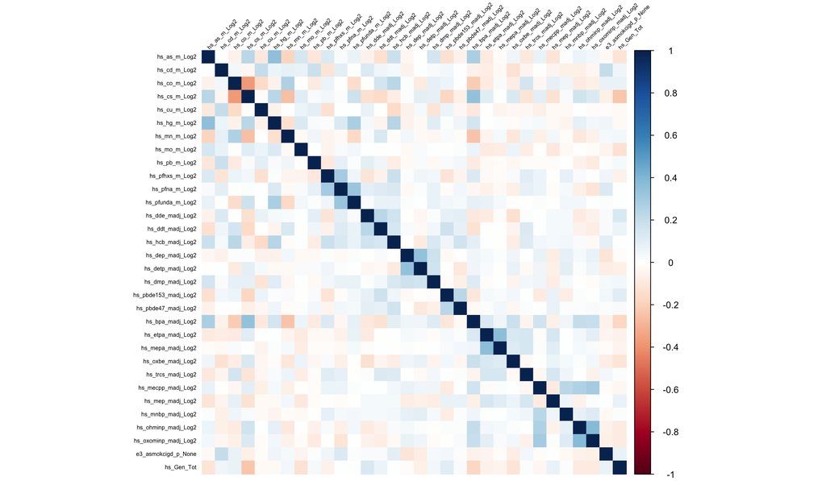

```r
numeric.train.data = train.data %>% select(where(is.numeric))
corplot = cor(numeric.train.data)
corrplot(corplot, method="color", tl.col="black", tl.srt=45, tl.cex = 0.5)
```

Based on the summary statistics for the 33 features in the training data, the log-transformed pre-natal chemical exposures have varying distributions across features, while the outcome appears to be right-skewed. Moreover, after removing correlated features, we can see there is no concerning multicollinearity between features in our training data.

### Step 2: Research Question

*What are the pre-natal exposures to chemicals (metals, organochlorines, organophosphate pesticides, PBDE, PFAS, phenols, tobacco smoke) that best predict childhood neurobehavioural internalizing and externalizing problems (as measured on the CBCL scale)?*

### Step 3: Implement pipeline to address research question

For feature selection, we will use a LASSO algorithm to identify the features that best predict childhood internalizing/externalizing problems through the CBCL scale. The model will be trained using 10-fold cross-validation on data that is centered and scaled, with the alpha value fixed to 1 and using a search grid of 100 values between 10^(-0.5) and 10^(0.5) to tune lambda. The best tune will be selected based on the lowest RMSE.

```r
set.seed(123)

#Create grid to search lambda
lambda = 10^seq(-0.5, 0.5, length = 100)

#Fit model with tuneGrid
mod_lasso = train(hs_Gen_Tot ~ ., data = train.data, method = "glmnet",
                  trControl = trainControl("cv", number = 10),
                  tuneGrid = expand.grid(alpha = 1, lambda = lambda),
                  preProcess = c("center", "scale"))

#Print the values of alpha and lambda that gave best prediction
mod_lasso$bestTune
```

```
##    alpha    lambda
## 43     1 0.8399287
```

```r
mod_lasso$results %>%
  arrange(RMSE) %>%
  head(5) %>%
  kbl(digits = 4) %>%
  kable_classic("hover")
```

| alpha | lambda | RMSE | Rsquared | MAE | RMSESD | RsquaredSD | MAESD |
| --- | --- | --- | --- | --- | --- | --- | --- |
| 1 | 0.8399 | 18.8063 | 0.0897 | 14.3234 | 2.6636 | 0.0505 | 1.2637 |
| 1 | 0.8206 | 18.8065 | 0.0896 | 14.3222 | 2.6645 | 0.0505 | 1.2650 |
| 1 | 0.8597 | 18.8070 | 0.0898 | 14.3247 | 2.6630 | 0.0505 | 1.2625 |
| 1 | 0.8018 | 18.8070 | 0.0894 | 14.3212 | 2.6654 | 0.0505 | 1.2661 |
| 1 | 0.7833 | 18.8077 | 0.0892 | 14.3204 | 2.6664 | 0.0505 | 1.2670 |

```r
coef(mod_lasso$finalModel, mod_lasso$bestTune$lambda)
```

```
## 34 x 1 sparse Matrix of class "dgCMatrix"
##                                            s1
## (Intercept)                      24.673091636
## hs_as_m_Log2                      .
## hs_cd_m_Log2                      .
## hs_co_m_Log2                      .
## hs_cs_m_Log2                     -2.923622929
## hs_cu_m_Log2                      .
## hs_hg_m_Log2                      .
## hs_mn_m_Log2                      .
## hs_mo_m_Log2                     -0.906266477
## hs_pb_m_Log2                      .
## hs_pfhxs_m_Log2                   .
## hs_pfna_m_Log2                    .
## hs_pfunda_m_Log2                  .
## hs_dde_madj_Log2                  1.093368304
## hs_ddt_madj_Log2                  .
## hs_hcb_madj_Log2                  .
## hs_dep_madj_Log2                  .
## hs_detp_madj_Log2                -0.015568698
## hs_dmp_madj_Log2                  0.589033901
## hs_pbde153_madj_Log2              0.291616061
## hs_pbde47_madj_Log2               .
## hs_bpa_madj_Log2                 -0.983150138
## hs_etpa_madj_Log2                 .
## hs_mepa_madj_Log2                -0.067750524
## hs_oxbe_madj_Log2                -0.452268024
## hs_trcs_madj_Log2                 .
## hs_mecpp_madj_Log2                .
## hs_mep_madj_Log2                  .
## hs_mnbp_madj_Log2                 .
## hs_ohminp_madj_Log2              -0.003388326
## hs_oxominp_madj_Log2             -0.036941966
## e3_asmokcigd_p_None               .
## hs_cotinine_mcat_NoneSHS smokers  .
## hs_cotinine_mcat_NoneSmokers      1.753211298
```

```r
varImp(mod_lasso$finalModel) %>% arrange(desc(Overall)) %>% head(15)
```

```
##                                  Overall
## hs_cs_m_Log2                 2.923622929
## hs_cotinine_mcat_NoneSmokers 1.753211298
## hs_dde_madj_Log2             1.093368304
## hs_bpa_madj_Log2             0.983150138
## hs_mo_m_Log2                 0.906266477
## hs_dmp_madj_Log2             0.589033901
## hs_oxbe_madj_Log2            0.452268024
## hs_pbde153_madj_Log2         0.291616061
## hs_mepa_madj_Log2            0.067750524
## hs_oxominp_madj_Log2         0.036941966
## hs_detp_madj_Log2            0.015568698
## hs_ohminp_madj_Log2          0.003388326
## hs_as_m_Log2                 0.000000000
## hs_cd_m_Log2                 0.000000000
## hs_co_m_Log2                 0.000000000
```

#### Final model evaluation

Finally, we will evaluate the performance our final LASSO model by making predictions in the test data. We will use the `postResample()` function to get performance measures of RMSE, R-squared, and MAE of the model on the test data.

```r
# Make predictions in test set
lasso_pred = mod_lasso %>% predict(test.data)
test.data = test.data %>% mutate(lasso_pred = lasso_pred)

# Model prediction performance
postResample(pred = lasso_pred, obs = test.data$hs_Gen_Tot) %>%
  kbl(digits = 4) %>%
  kable_classic("hover")
```

|  | x |
| --- | --- |
| RMSE | 16.8115 |
| Rsquared | 0.0494 |
| MAE | 13.5569 |

The final model results in an RMSE of 16.81 and R-squared of 0.049. This may suggest limited predictive performance of our LASSO model. Next steps to address the research question could be to evaluate the importance of the identified features by introducing covariates that are hypothesized to be confounders in the model, or run other feature selection models to see if there are better-performing predictive models and to compare whether the same features were selected to be important across algorithms.